# Homework 2

Tony Daza

2022-10-13

Here we go with a bunch of plots. For this we are going to use the nlme package and the Oxboys data for the first two plots.

Don’t ask me what the data is about because I don’t know. But without furtherado… the plots

Just kidding, first we need to clean the data. And then the plots.

```r
#install.packages("nlme")

library(needs)
#We also need tidyverse for ggplot2 and janitor to clean the names
#Our dataset is in nlme
needs(tidyverse, janitor, nlme)

#Just a little cleaning
pd <- Oxboys %>%
  clean_names() %>%
  mutate(subject = factor(subject),
         occasion = factor(occasion)) %>%
  filter(subject == "10" | subject == "4" | subject == "7") %>%
  as_tibble()
```

Great, now that the data is loaded and cleaned, we will create “Plot 1”

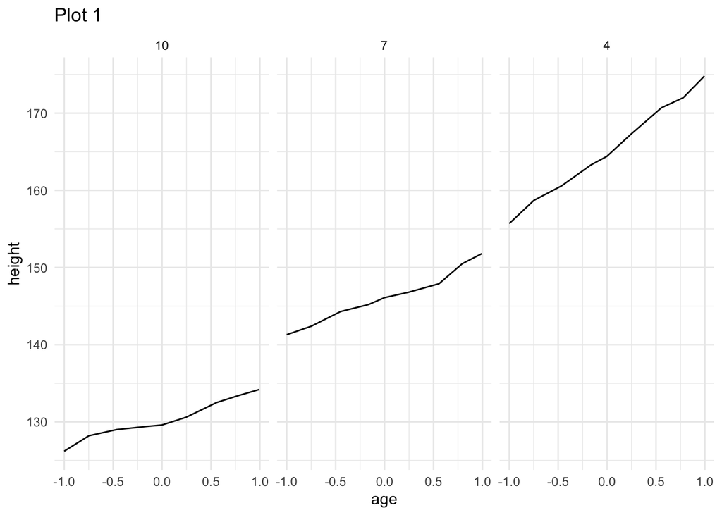

```r
#Plot 1
##A facet wrapped line plot

pd %>% ggplot(aes(x=age, y=height)) +
  geom_line()+
  theme_minimal()+
  labs(x="age", y= "height", title = "Plot 1")+
  facet_wrap(~subject)
```

And so we move on to “Plot 2” which is a line graph of age and height by participant but unlike “Plot 1” it is not faceted but instead it is colored by participant.

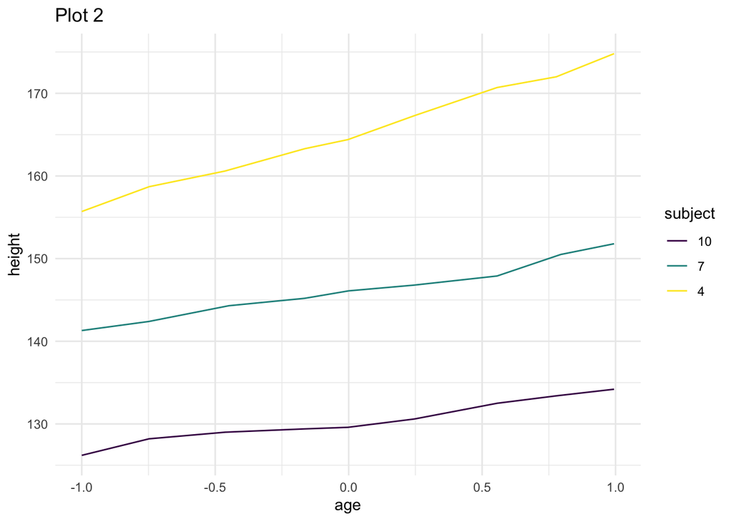

```r
#A line plot but not facet wrapped
pd %>% ggplot(aes(x=age, y=height)) +
  geom_line(aes(color = subject))+
  theme_minimal()+
  labs(x="age", y= "height", title = "Plot 2")
```

That concludes our examination of the Oxboys dataset. Now we shall look at the mtcars data set from base R.

It is about cars and miles per gallon (mpg).

Plot 3 will be a scatterplot of mpg and drat (Unsure what exactly this variable is. I would need to examine the dataset)

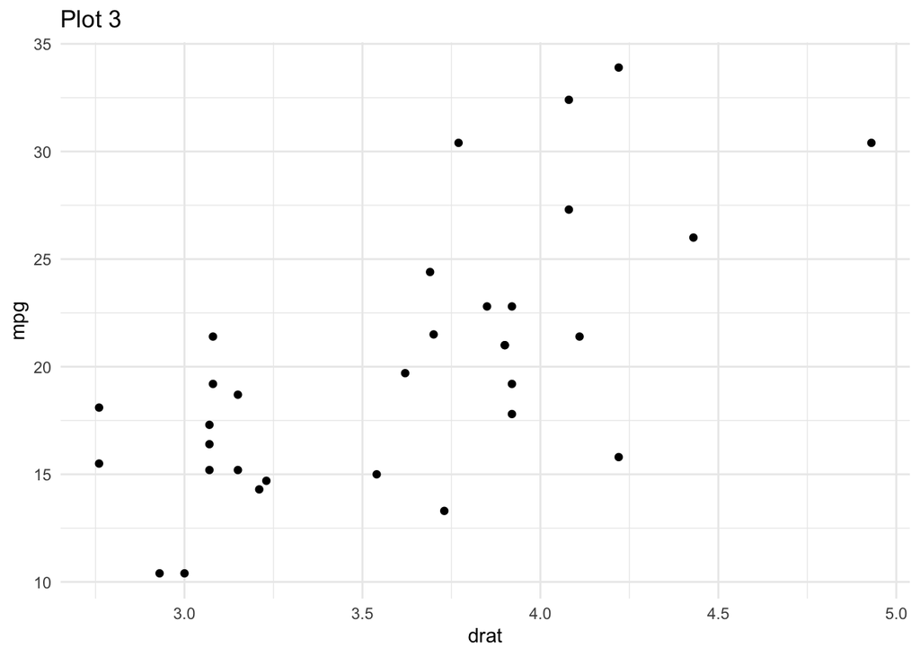

```r
#scatter plot of mpg and drat
mtcars %>%
  ggplot(aes(x=drat, y = mpg))+
  geom_point()+
  theme_minimal()+
  labs(title = "Plot 3")
```

Plot 4 just layers on a trend line with a confidence interval shaded on. Otherwise we are still examining a scatterplot of mpg and drat.

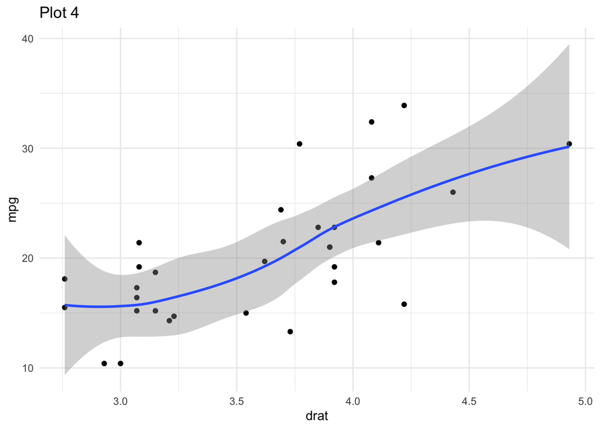

```r
#Plot 4. Scatterplot with trendline
mtcars %>%
  ggplot(aes(x=drat, y = mpg))+
  geom_point()+
  geom_smooth()+
  theme_minimal()+
  labs(title = "Plot 4")
```

I am guessing you are getting bored of these graphs by now. Me too. But here is another scatterplot for you. Except this one is facet wrapped by a binary variable. So here is Plot 5 for you.

```r
#Plot 5 Scatter plot that is facet wrapped
head(mtcars)
```

```
##                    mpg cyl disp  hp drat    wt  qsec vs am gear carb
## Mazda RX4         21.0   6  160 110 3.90 2.620 16.46  0  1    4    4
## Mazda RX4 Wag     21.0   6  160 110 3.90 2.875 17.02  0  1    4    4
## Datsun 710        22.8   4  108  93 3.85 2.320 18.61  1  1    4    1
## Hornet 4 Drive    21.4   6  258 110 3.08 3.215 19.44  1  0    3    1
## Hornet Sportabout 18.7   8  360 175 3.15 3.440 17.02  0  0    3    2
## Valiant           18.1   6  225 105 2.76 3.460 20.22  1  0    3    1
```

Based on a quick peak, two variables are binary: vs and am Let’s start by wrapping using the ‘vs’ variable

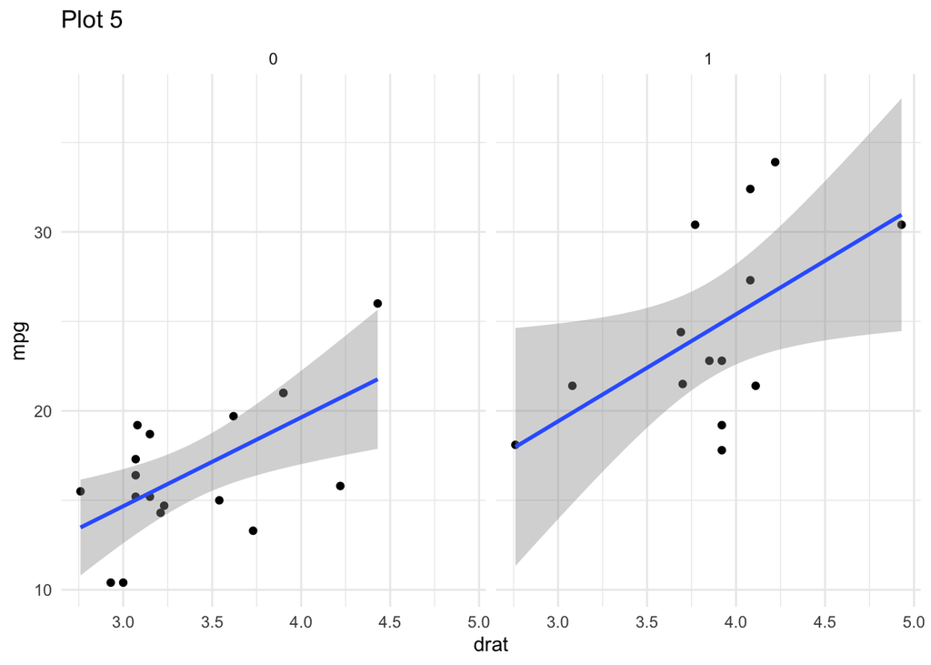

```r
#Plot 5
mtcars %>%
  ggplot(aes(x=drat, y = mpg))+
  geom_point()+
  geom_smooth(method = 'lm')+
  theme_minimal()+
  labs(title = "Plot 5")+
  facet_wrap(~vs)
```

Oh hey it worked. I did change the method to a linear model from the default but now it looks right. Quite a large confidence interval though. Maybe not the best fitting method.

Well now on to plot 6.

Sticking with mpg vs drat but now grouping by cylinders

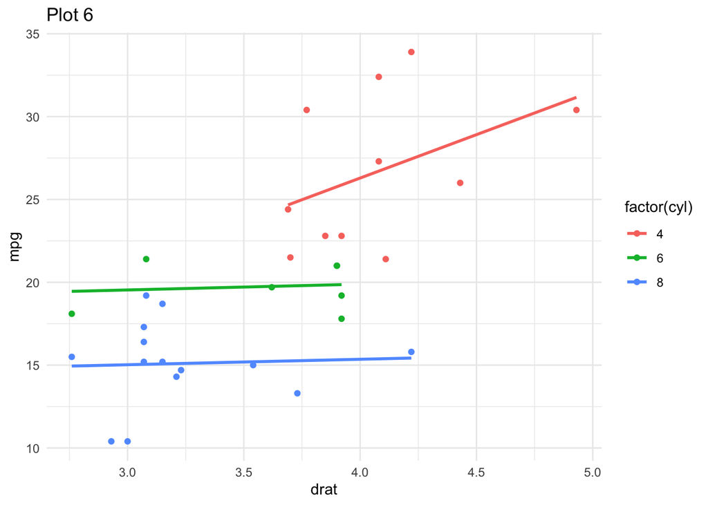

```r
#Plot 6, scatter plot but grouping by cylinders
ggplot(mtcars, aes(x=drat, y = mpg, color = factor(cyl)))+
  geom_point()+
  geom_smooth(se = FALSE, method = 'lm')+
  theme_minimal()+
  labs(title = "Plot 6")
```

And now for my final dataset: Orange.

Plot 7, a line graph with pretty colors

But first, I should examine this Orange data

```r
#examining orange data
head(Orange)
```

```
## Grouped Data: circumference ~ age | Tree
##   Tree  age circumference
## 1    1  118            30
## 2    1  484            58
## 3    1  664            87
## 4    1 1004           115
## 5    1 1231           120
## 6    1 1372           142
```

Seems like it is really just circumference of the tree by the age

Plot 7

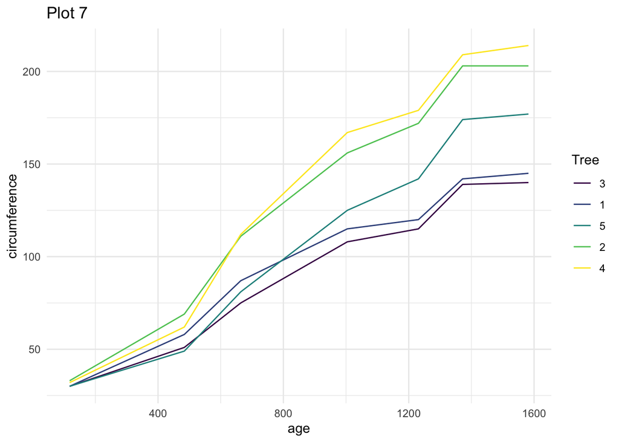

```r
#Step 2: Plot 7
Orange %>%
  ggplot(aes(x=age, y = circumference))+
  geom_line(aes(color=Tree))+
  theme_minimal()+
  labs(title = "Plot 7")
```

Great, now let’s make this look better… add some labels and a title and maybe a trendline too

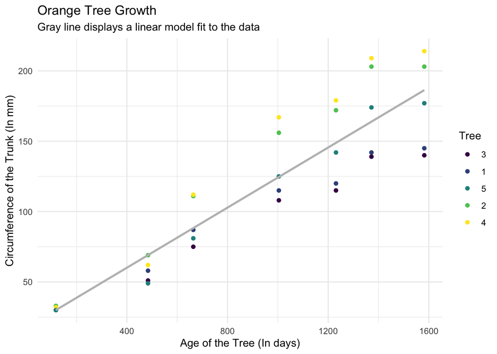

```r
#Plot 8
Orange %>%
  ggplot(aes(x=age, y = circumference))+
  geom_point(aes(color=Tree))+
  theme_minimal()+
  geom_smooth(method = 'lm', se = FALSE, color = 'gray')+
  labs(title = "Orange Tree Growth", subtitle = "Gray line displays a linear model fit to the data", x = "Age of the Tree (In days)", y = "Circumference of the Trunk (In mm)")
```

The END